# HR_ANALYSIS

Tapas_Mohanty

18 March 2018

References —————– 1. https://www.kaggle.io/svf/441884/647b8c07ae7a081c547af6d9324351c1/__results__.html 2. https://www.kaggle.com/aiswaryaramachandran/d/ludobenistant/hr-analytics/exploratory-analysis Problem——————- Why are our best and most experienced employees leaving prematurely? Try to predict which valuable employees will leave next. Fields in the dataset include: Employee satisfaction level Last evaluation Number of projects Average monthly hours Time spent at the company Whether they have had a work accident Whether they have had a promotion in the last 5 years Sales Salary Whether the employee has left

1. Clear objects, call libraries and read file —————–

```r
rm(list=ls()) ; gc()
```

```
##          used (Mb) gc trigger (Mb) max used (Mb)
## Ncells 477600 25.6     750400 40.1   592000 31.7
## Vcells 889498  6.8    1650153 12.6  1087347  8.3
```

```r
library(dplyr)       # select statement, %>% etc
```

```r
library(corrplot)    # Correlation plots
library(ggplot2)
library(gridExtra)   # Grid of plots
```

2. Set working directory

```r
setwd("/home/tapas/HR_NEw/")
hr<-read.csv("hr.csv",header = T)
dim(hr)
```

```
## [1] 14999    10
```

```r
names(hr)
```

```
##  [1] "satisfaction_level"          "last_evaluation_score"
##  [3] "number_projects"             "average_montly_hours_worked"
##  [5] "time_spend_company"          "Work_accident"
##  [7] "left"                        "promotion_last_5years"
##  [9] "department"                  "salary"
```

```r
str(hr)
```

```
## 'data.frame':    14999 obs. of  10 variables:
##  $ satisfaction_level         : num  0.38 0.8 0.11 0.72 0.37 0.41 0.1 0.92 0.89 0.42 ...
##  $ last_evaluation_score      : num  0.53 0.86 0.88 0.87 0.52 0.5 0.77 0.85 1 0.53 ...
##  $ number_projects            : int  2 5 7 5 2 2 6 5 5 2 ...
##  $ average_montly_hours_worked: int  157 262 272 223 159 153 247 259 224 142 ...
##  $ time_spend_company         : int  3 6 4 5 3 3 4 5 5 3 ...
##  $ Work_accident              : int  0 0 0 0 0 0 0 0 0 0 ...
##  $ left                       : int  1 1 1 1 1 1 1 1 1 1 ...
##  $ promotion_last_5years      : int  0 0 0 0 0 0 0 0 0 0 ...
##  $ department                 : Factor w/ 10 levels "accounting","hr",..: 8 8 8 8 8 8 8 8 8 8 ...
##  $ salary                     : Factor w/ 3 levels "high","low","medium": 2 3 3 2 2 2 2 2 2 2 ...
```

3. First visualisations ———— This graph present the correlations between each variables. The size of the bubbles reveal the significance of the correlation, while the colour present the direction (either positive or negative). On average people who leave have a low satisfaction level, they work more and didn’t get promoted within the past five years.

3.1

```r
HR_correlation <- hr %>% select(satisfaction_level:promotion_last_5years)
```

3.2

```r
M <- cor(HR_correlation)
M
```

```
##                             satisfaction_level last_evaluation_score
## satisfaction_level                  1.00000000           0.105021214
## last_evaluation_score               0.10502121           1.000000000
## number_projects                    -0.14296959           0.349332589
## average_montly_hours_worked        -0.02004811           0.339741800
## time_spend_company                 -0.10086607           0.131590722
## Work_accident                       0.05869724          -0.007104289
## left                               -0.38837498           0.006567120
## promotion_last_5years               0.02560519          -0.008683768
##                             number_projects average_montly_hours_worked
## satisfaction_level             -0.142969586                -0.020048113
## last_evaluation_score           0.349332589                 0.339741800
## number_projects                 1.000000000                 0.417210634
## average_montly_hours_worked     0.417210634                 1.000000000
## time_spend_company              0.196785891                 0.127754910
## Work_accident                  -0.004740548                -0.010142888
## left                            0.023787185                 0.071287179
## promotion_last_5years          -0.006063958                -0.003544414
##                             time_spend_company Work_accident        left
## satisfaction_level                -0.100866073   0.058697241 -0.38837498
## last_evaluation_score              0.131590722  -0.007104289  0.00656712
## number_projects                    0.196785891  -0.004740548  0.02378719
## average_montly_hours_worked        0.127754910  -0.010142888  0.07128718
## time_spend_company                 1.000000000   0.002120418  0.14482217
## Work_accident                      0.002120418   1.000000000 -0.15462163
## left                               0.144822175  -0.154621634  1.00000000
## promotion_last_5years              0.067432925   0.039245435 -0.06178811
##                             promotion_last_5years
## satisfaction_level                    0.025605186
## last_evaluation_score                -0.008683768
## number_projects                      -0.006063958
## average_montly_hours_worked          -0.003544414
## time_spend_company                    0.067432925
## Work_accident                         0.039245435
## left                                 -0.061788107
## promotion_last_5years                 1.000000000
```

The areas of circles or squares show the absolute value of corresponding correlation coefficients. Color intensity and the size of the circle are proportional to the correlation coefficients.

3.3

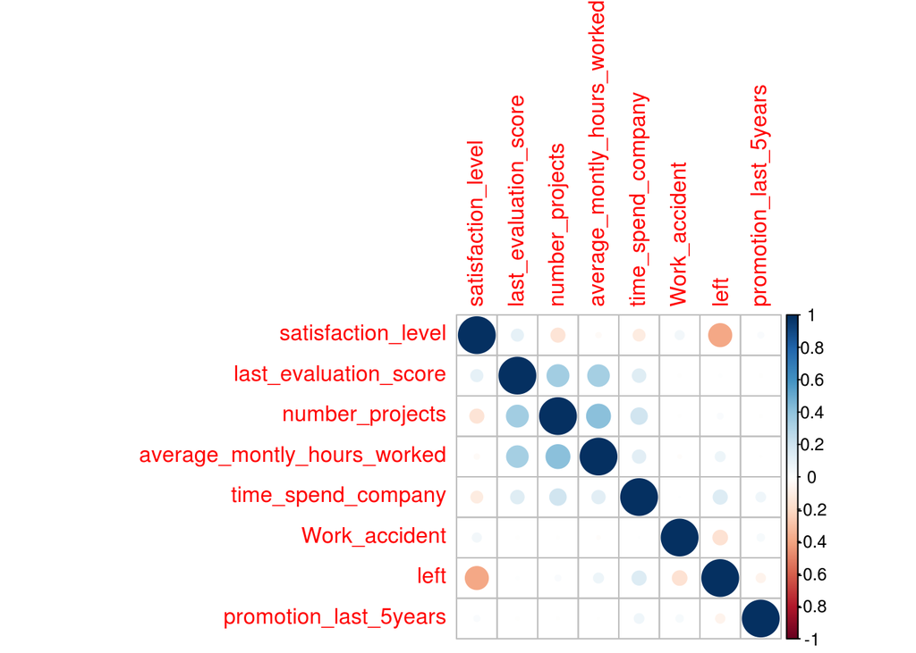

```r
corrplot(M)
```

3.4

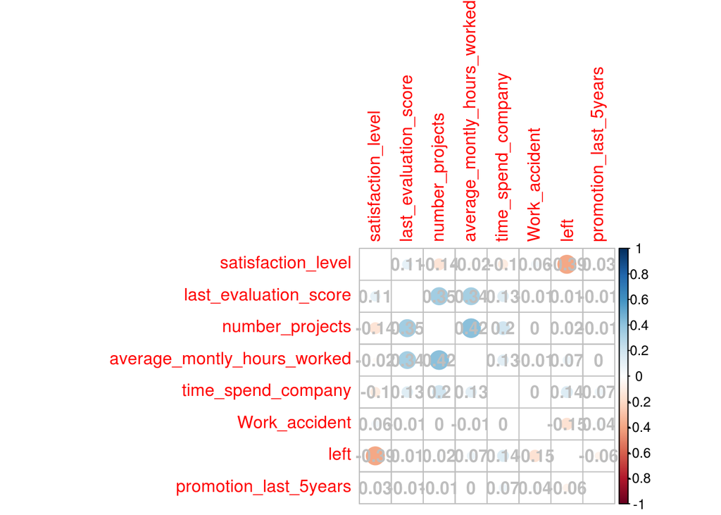

```r
corrplot(M, method="circle", diag = F, addCoef.col = "grey")
```

3.5

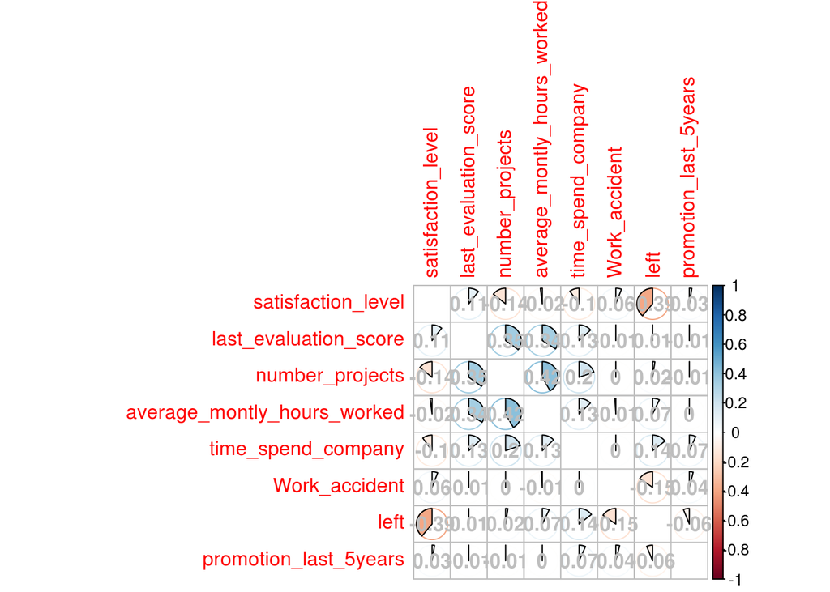

```r
corrplot(M, method="pie", diag = F, addCoef.col = "grey")
```

3.6

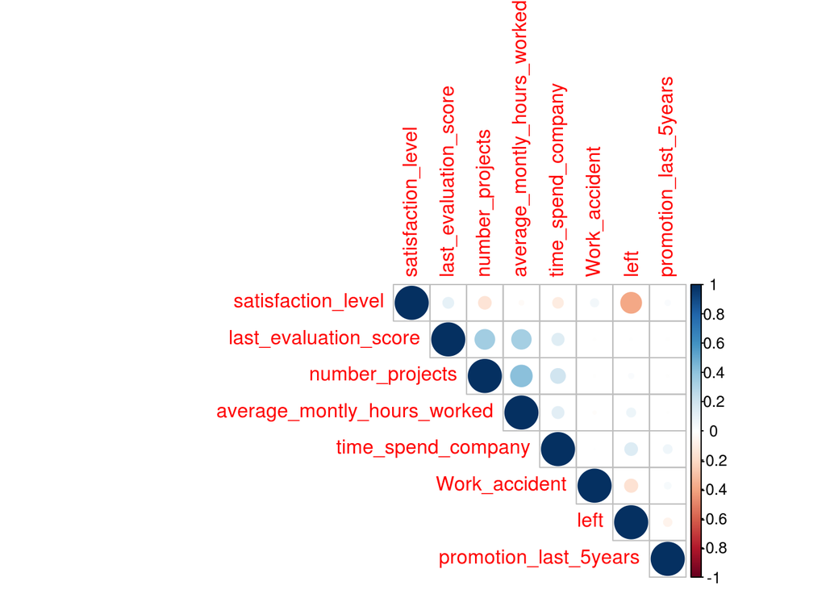

```r
corrplot(M, type="upper")
```

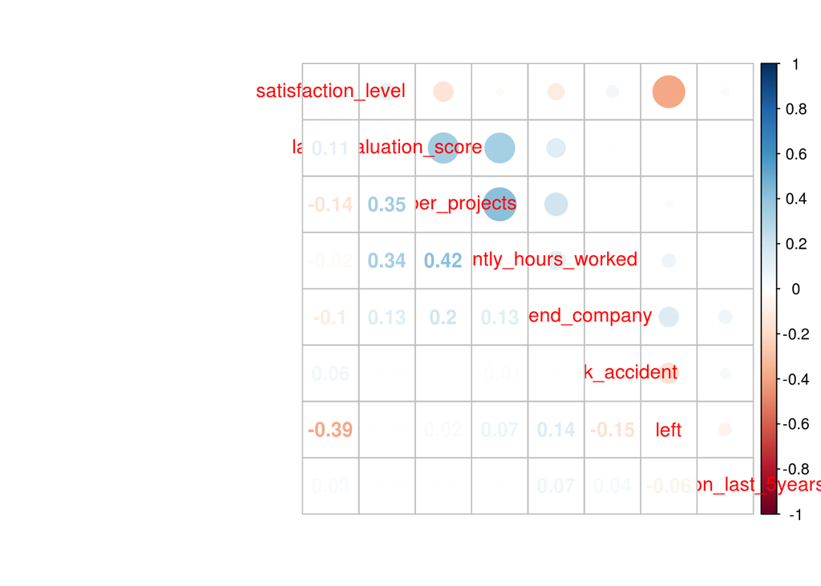

```r
corrplot.mixed(M)
```

3.7

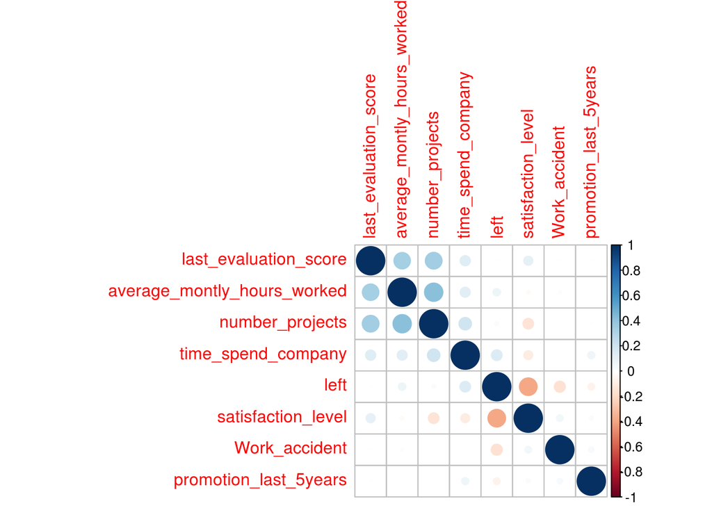

```r
corrplot(M, order ="AOE")
```

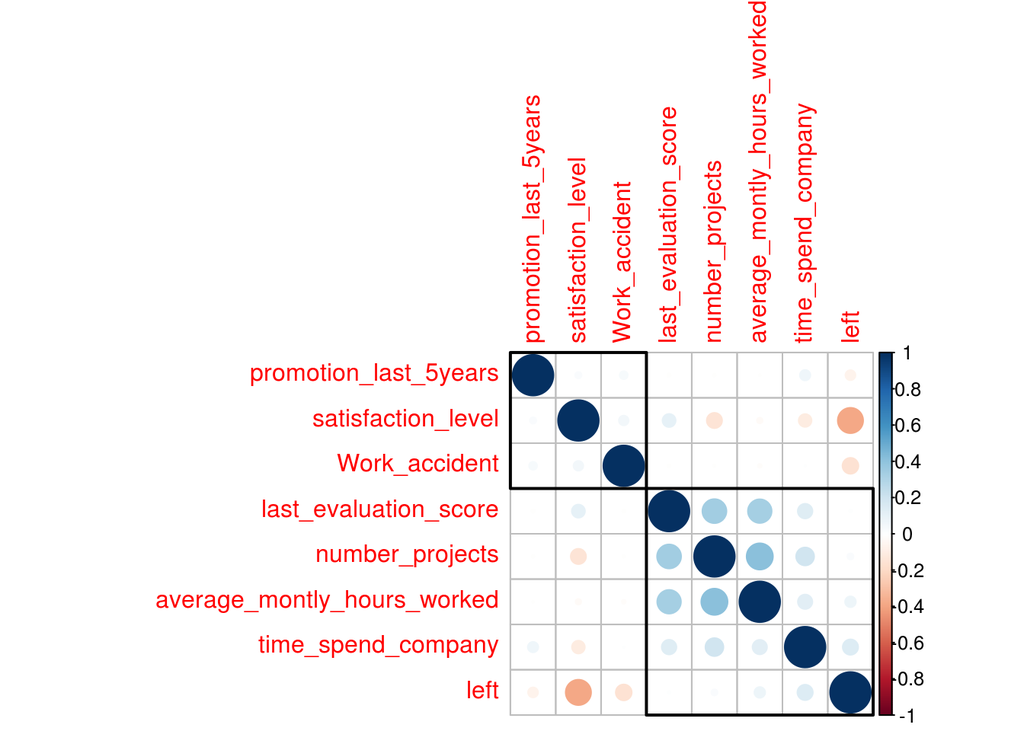

```r
corrplot(M, order="hclust", addrect=2)
```

Who is leaving?————–

```r
# 4. Filter only those who have left
hr_left <- hr %>% filter(left==1)
# 4.1 How many?
nrow(hr_left)
```

```
## [1] 3571
```

5. Let’s create a data frame with only the people that have left the company, so we can visualise what is the distribution of each features:

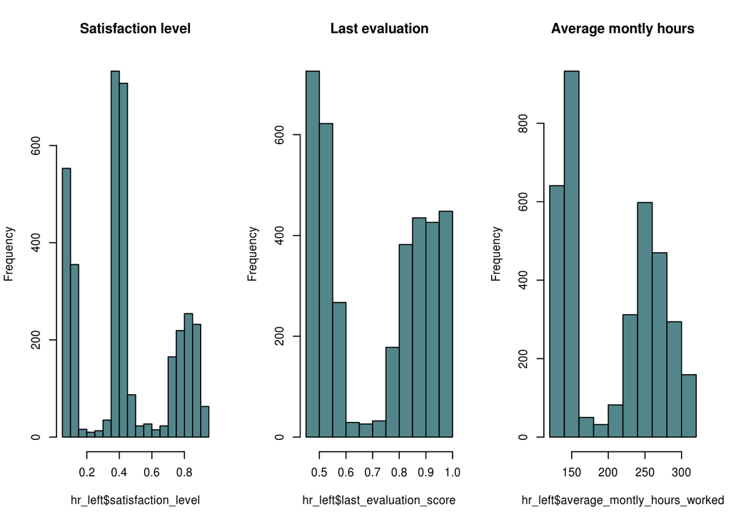

```r
# 5.1 Divide plot window in 1 X 3 part
#     R colour names http://www.stat.columbia.edu/~tzheng/files/Rcolor.pdf
par(mfrow=c(1,3))
# 5.2
hist(hr_left$satisfaction_level,col="cadetblue4", main = "Satisfaction level")
hist(hr_left$last_evaluation_score,col="cadetblue4", main = "Last evaluation")
hist(hr_left$average_montly_hours_worked,col="cadetblue4", main = "Average montly hours")
```

6. What about accidents and salary Divide plot window in 1 X 2 parts

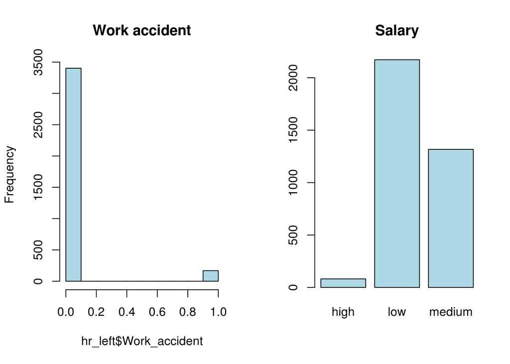

```r
par(mfrow=c(1,2))
# 6.1
hist(hr_left$Work_accident,col="lightblue", main = "Work accident")
plot(hr_left$salary,col="lightblue", main = "Salary")
```

From above plots We can see why we don’t want to retain everybody. Some people don’t work well as we can see from their evaluation, but clearly there are also many good workers that leave.

7. Why good people leave?—————- 7.1 How many among those leaving are Good people

```r
nrow(hr_left)
```

```
## [1] 3571
```

7.2

```r
hr_good_leaving_people <- hr_left %>% filter(last_evaluation_score >= 0.70 | time_spend_company >= 4 | number_projects > 5)
nrow(hr_good_leaving_people)
```

```
## [1] 2014
```

7.3 Percentage of good people leaving

```r
nrow(hr_good_leaving_people)/nrow(hr_left)
```

```
## [1] 0.5639877
```

8. Let’s analyse data of only the most valuable employees (whether left or NOT left) and see why they tend to leave. 8.1

```r
hr_allgood_people <- hr %>% filter(last_evaluation_score >= 0.70 | time_spend_company >= 4 | number_projects > 5)
```

8.2

```r
hr_allgood_people_select <- hr_allgood_people %>% select(satisfaction_level, number_projects: promotion_last_5years)
```

8.3

```r
M <- cor(hr_allgood_people_select)
```

8.4 From below plot it’s much clearer. On average valuable employees that ‘left’ are not satisfayed, work on many projects, spend many hours in the company each month and aren’t promoted.

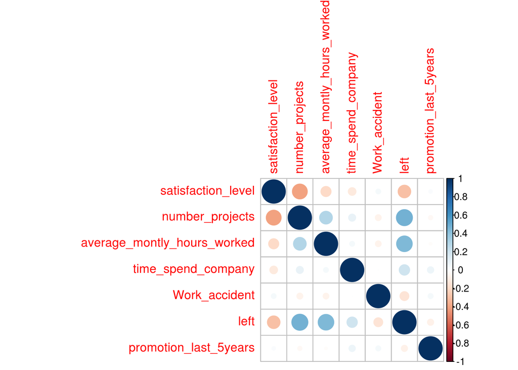

```r
corrplot(M, method="circle")
```

```r
summary(hr_allgood_people)
```

```
##  satisfaction_level last_evaluation_score number_projects
##  Min.   :0.090      Min.   :0.3600        Min.   :2.000
##  1st Qu.:0.490      1st Qu.:0.7300        1st Qu.:3.000
##  Median :0.680      Median :0.8300        Median :4.000
##  Mean   :0.617      Mean   :0.8015        Mean   :4.159
##  3rd Qu.:0.830      3rd Qu.:0.9100        3rd Qu.:5.000
##  Max.   :1.000      Max.   :1.0000        Max.   :7.000
##
##  average_montly_hours_worked time_spend_company Work_accident
##  Min.   : 96.0               Min.   : 2.000     Min.   :0.0000
##  1st Qu.:171.0               1st Qu.: 3.000     1st Qu.:0.0000
##  Median :218.0               Median : 4.000     Median :0.0000
##  Mean   :211.8               Mean   : 3.916     Mean   :0.1521
##  3rd Qu.:253.0               3rd Qu.: 5.000     3rd Qu.:0.0000
##  Max.   :310.0               Max.   :10.000     Max.   :1.0000
##
##       left        promotion_last_5years       department      salary
##  Min.   :0.0000   Min.   :0.00000       sales      :2628   high  : 834
##  1st Qu.:0.0000   1st Qu.:0.00000       technical  :1786   low   :4671
##  Median :0.0000   Median :0.00000       support    :1466   medium:4267
##  Mean   :0.2061   Mean   :0.02384       IT         : 808
##  3rd Qu.:0.0000   3rd Qu.:0.00000       product_mng: 582
##  Max.   :1.0000   Max.   :1.00000       marketing  : 561
##                                         (Other)    :1941
```

```r
hr$salary<-ordered(hr$salary,levels=c("low","medium","high"))
```

Management Department, has the least attrition rate as it has a higher proportion of highly paid employees. There is almost no attrition in High Salary Paid Employees.

9.2. How are total employees distributed department wise

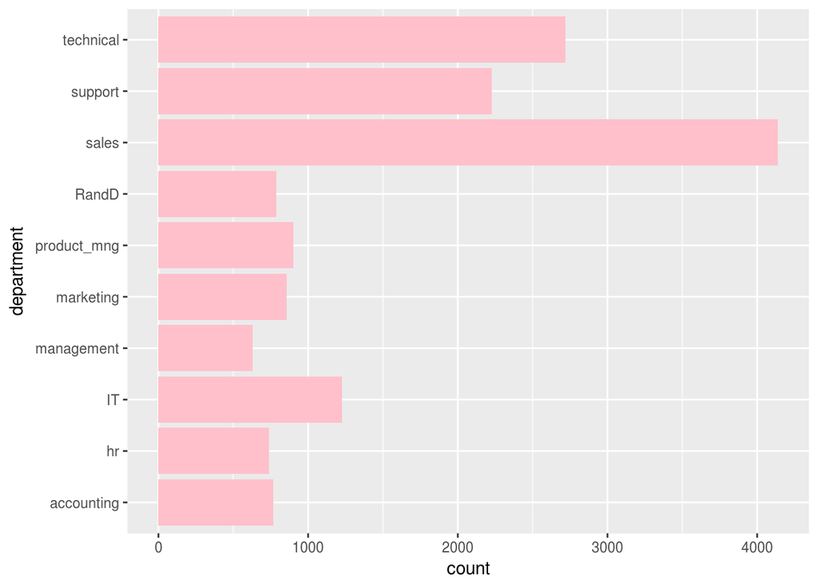

```r
plot_department<-ggplot(hr,aes(x=department))+geom_bar(fill="pink")+coord_flip()
plot_department
```

9.3 . How is salary-scale distributed (sort of histogram of salary)

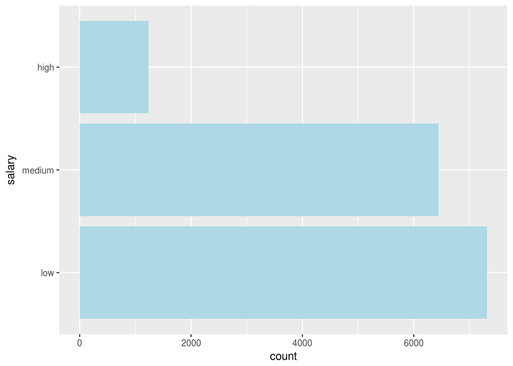

```r
plot_salary<-ggplot(hr,aes(x=salary))+geom_bar(fill="lightblue")+coord_flip()
plot_salary
```

9.4. Create a department-wise bar chart and show in stacked fashion, proportion of people left geom_bar(position=“fill”) makes it easier to compare proportions

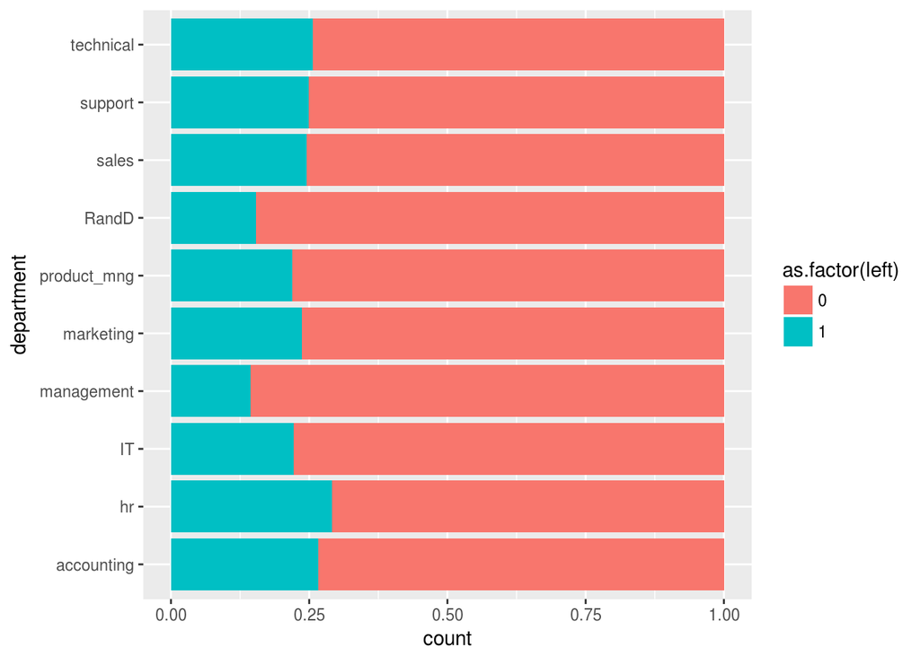

```r
plot_department_left<-ggplot(hr,aes(x=department,fill=as.factor(left)))+geom_bar(position="fill")+coord_flip() # +scale_fill_brewer(palette="PiYG")
plot_department_left
```

9.5. How is salary distributed between those who left and did not. Did high salaried people leave?

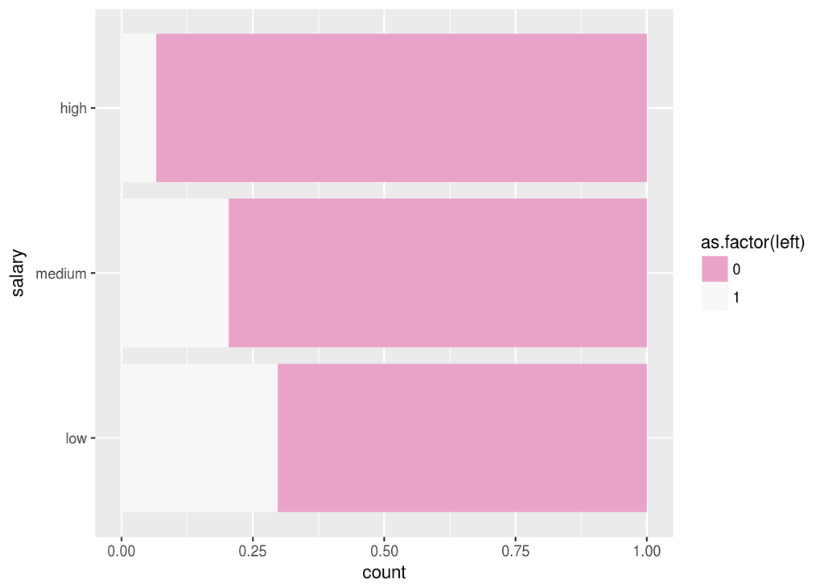

```r
plot_salary_left<-ggplot(hr,aes(x=salary,fill=as.factor(left)))+geom_bar(position="fill")+coord_flip()+scale_fill_brewer(palette="PiYG")
plot_salary_left
```

9.6. Department wise, how salaried emploees are distributed. Does every dept have same ratio of low, medium and high salaried people?

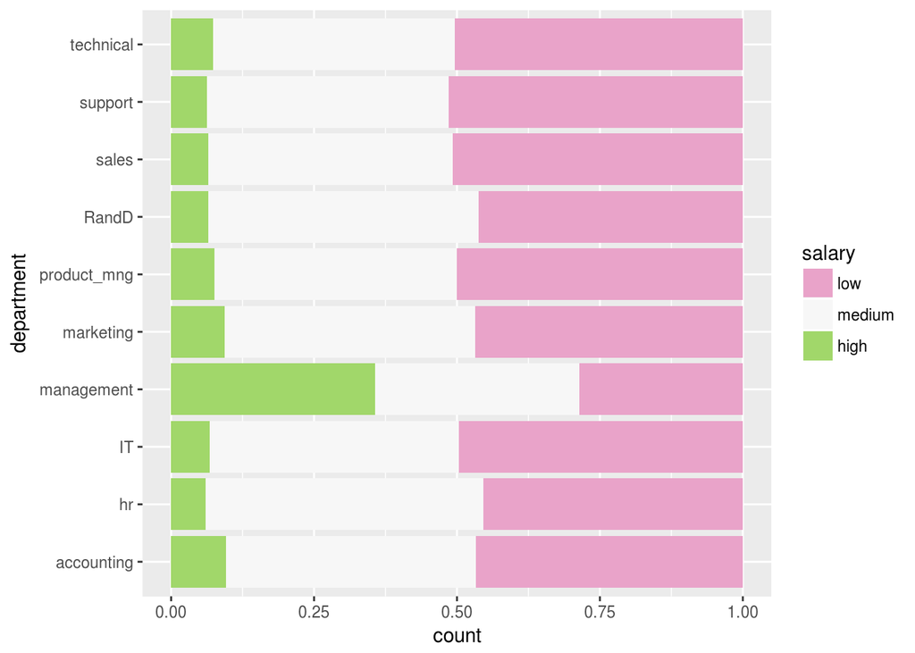

```r
plot_salary_department<-ggplot(hr,aes(x=department,fill=salary))+geom_bar(position="fill")+scale_fill_brewer(palette="PiYG")+coord_flip()
plot_salary_department
```

9.7 Arrange all above plots in a grid

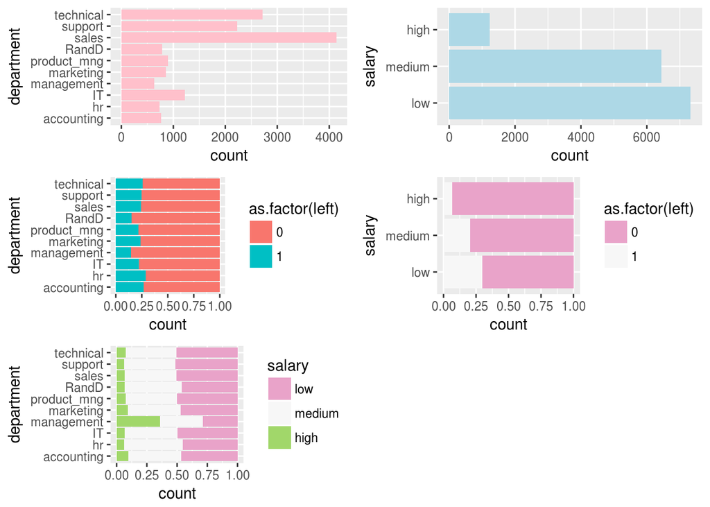

```r
grid.arrange(plot_department,plot_salary,plot_department_left,plot_salary_left,plot_salary_department,ncol=2)
```

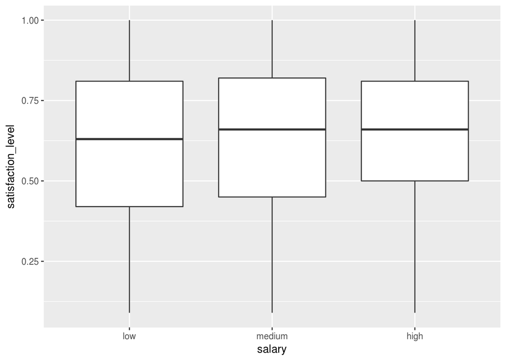

```r
plot_sal_left_satisfaction<-ggplot(hr,aes(x=salary,y=satisfaction_level))+geom_boxplot()
plot_sal_left_satisfaction
```